# An Introduction to Statistical Learning (2013)

Chapter Code

by Brian Hassett

# Chapter 4 Classification

This notebook is a rough outline of **Chapter 4** of **An Introduction to Statistical Learning** (James et al. (2013)[^1]).

The authors do not provide code for the analysis or figures used throughout each chapter. They do however provide access to some of the data. This notebook uses the data to recreate *some* of the analysis and figures from the chapter.

## Setup

```r
library(ISLR)
library(tidyverse)
library(patchwork)
theme_set(theme_bw())

# Given a filename, return the filepath. Default folder is the `data` folder in the current working directory.
get_path <- function(filename) {
  str_c(getwd(), "data", filename, sep = "/")
}

# Return a table (matrix) of the coefficients of a linear model:
get_regression_coefs <- function(model, rounding) {
  table <- summary(model)$coef
  return(round(table, rounding))
}

# Colors:
ISLR_blue <- "#176FC0"
ISLR_orange <- "#D99411"
ISLR_brown <- "#94340E"
```

## 4.1 An Overview of Classification

View the `Default` data:

```r
Default
```

| default | student | balance | income |
| --- | --- | --- | --- |
| No | No | 729.5264952 | 44361.625 |
| No | Yes | 817.1804066 | 12106.135 |
| No | No | 1073.5491640 | 31767.139 |
| No | No | 529.2506047 | 35704.494 |
| No | No | 785.6558829 | 38463.496 |
| No | Yes | 919.5885305 | 7491.559 |
| No | No | 825.5133305 | 24905.227 |
| No | Yes | 808.6675043 | 17600.451 |
| No | No | 1161.0578540 | 37468.529 |
| No | No | 0.0000000 | 29275.268 |

[output cut: 990 more lines]

Proportions:

```r
Default %>%
  count(default) %>%
  mutate(prop = n/sum(n))
```

|  | default | n | prop |
| --- | --- | --- | --- |
| 1 | No | 9667 | 0.9667 |
| 2 | Yes | 333 | 0.0333 |

### FIGURE 4.1

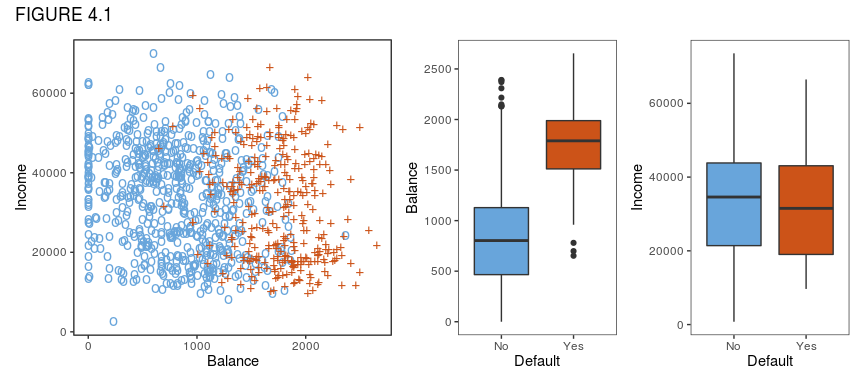

```r
colors_4.1 <- c("blue" = "#68A5DB",
                "orange" = "#CC5318")

# Subset the data by taking all defaulters plus a sample of non-defaulters:
no <- which(Default$default == "No")
yes <- which(Default$default == "Yes")
flag <- c(sample(no, 2*length(yes)), yes)

p1 <- Default[flag, ] %>%
  #sample_n(1000) %>%
  ggplot() +
  geom_point(aes(balance, income, color = default, shape = default),
             size = 4,
             show.legend = FALSE) +
  labs(x = "Balance", y = "Income") +
  scale_color_manual(values = c(colors_4.1[["blue"]], colors_4.1[["orange"]])) +
  #scale_color_manual(values = c("blue", ))
  scale_shape_manual(values = c('o', '+')) +
  theme(panel.grid = element_blank())

# Use all data:
p2 <- Default %>%
  ggplot() +
  geom_boxplot(aes(default, balance, fill = default),
               show.legend = FALSE) +
  labs(x = "Default", y = "Balance") +
  scale_fill_manual(values = c(colors_4.1[["blue"]], colors_4.1[["orange"]])) +
  scale_y_continuous(breaks = seq(0, 2500, by = 500)) +
  theme(panel.grid = element_blank())

# Use all data:
p3 <- Default %>%
  ggplot() +
  geom_boxplot(aes(default, income, fill = default),
               show.legend = FALSE) +
  labs(x = "Default", y = "Income") +
  scale_fill_manual(values = c(colors_4.1[["blue"]], colors_4.1[["orange"]])) +
  scale_y_continuous(breaks = seq(0, 60000, by = 20000)) +
  theme(panel.grid = element_blank())

p1 + p2 + p3 + plot_layout(widths = c(2, 1, 1)) + plot_annotation(title = "FIGURE 4.1")
```

## 4.2 Why Not Linear Regression?

## 4.3 Logistic Regression

### FIGURE 4.2

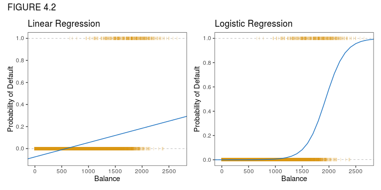

```r
# Recode the default variable as 0/1:
Default01 <- Default %>%
  mutate(default = if_else(default == "No", 0, 1))

# Linear regression model:
lm1 <- lm(default ~ balance, data = Default01)

# Prediction grid:
pred_grid <- data.frame(balance = seq(-200, 3000, 100))

# Add the linear regression model's predictions:
pred_grid$prob_lm1 <- predict(lm1, newdata = data.frame(balance = pred_grid$balance))

# Linear regression plot:
p1 <- ggplot() +
  geom_hline(yintercept = 1, linetype = "dashed", size = 0.1) +
  geom_hline(yintercept = 0, linetype = "dashed", size = 0.1) +
  geom_point(data = Default01,
             aes(balance, default),
             color = ISLR_orange, shape = "|", alpha = 0.7) +
  geom_line(data = pred_grid,
            aes(balance, prob_lm1),
            color = ISLR_blue) +
  labs(x = "Balance", y = "Probability of Default",
       title = "Linear Regression") +
  scale_x_continuous(breaks = seq(0, 2500, 500)) +
  scale_y_continuous(breaks = seq(0, 1, 0.2)) +
  coord_cartesian(xlim = c(0, 2700)) +
  theme(panel.grid = element_blank())

# Logistic regression model:
glm1 <- glm(default ~ balance, data = Default01, family = binomial)

# Add the logistic regression model's predictions:
pred_grid$prob_glm1 <- predict(glm1, newdata = data.frame(balance = pred_grid$balance), type = "response")

# Logistic regression plot:
p2 <- ggplot() +
  geom_hline(yintercept = 1, linetype = "dashed", size = 0.1) +
  geom_hline(yintercept = 0, linetype = "dashed", size = 0.1) +
  geom_point(data = Default01,
             aes(balance, default),
             color = ISLR_orange, shape = "|", alpha = 0.7) +
  geom_line(data = pred_grid,
            aes(balance, prob_glm1),
            color = ISLR_blue) +
  labs(x = "Balance", y = "Probability of Default",
       title = "Logistic Regression") +
  scale_x_continuous(breaks = seq(0, 2500, 500)) +
  scale_y_continuous(breaks = seq(0, 1, 0.2)) +
  coord_cartesian(xlim = c(0, 2700)) +
  theme(panel.grid = element_blank())

p1 + p2 + plot_annotation(title = "FIGURE 4.2")
```

### TABLE 4.1

```r
mod1 <- glm(default ~ balance, data = Default, family = binomial)
get_regression_coefs(mod1, 4)
```

```
            Estimate Std. Error  z value Pr(>|z|)
(Intercept) -10.6513     0.3612 -29.4922        0
balance       0.0055     0.0002  24.9531        0
```

Calculations on page 134:

```r
coefs <- coef(mod1)
x <- c(1000, 2000)
(exp(coefs[1] + coefs[2]*x))/(1 + exp(coefs[1] + coefs[2]*x))
```

```
[1] 0.005752145 0.585769370
```

### TABLE 4.2

```r
mod2 <- glm(default ~ student, data = Default, family = binomial)
get_regression_coefs(mod2, 4)
```

```
            Estimate Std. Error  z value Pr(>|z|)
(Intercept)  -3.5041     0.0707 -49.5542    0e+00
studentYes    0.4049     0.1150   3.5202    4e-04
```

Calculations on page 135:

```r
coefs <- coef(mod2)
x <- c(1, 0)
(exp(coefs[1] + coefs[2]*x))/(1 + exp(coefs[1] + coefs[2]*x))
```

```
[1] 0.04313859 0.02919501
```

### TABLE 4.3

```r
mod3 <- glm(default ~ balance + income + student, data = Default, family = binomial)
get_regression_coefs(mod3, 4)
```

```
            Estimate Std. Error  z value Pr(>|z|)
(Intercept) -10.8690     0.4923 -22.0801   0.0000
balance       0.0057     0.0002  24.7376   0.0000
income        0.0000     0.0000   0.3698   0.7115
studentYes   -0.6468     0.2363  -2.7376   0.0062
```

### FIGURE 4.3

The left part of this figure is not exactly like the book, not sure how to get the lines to look the same as the book, the bin widths and the range need to be tweaked)

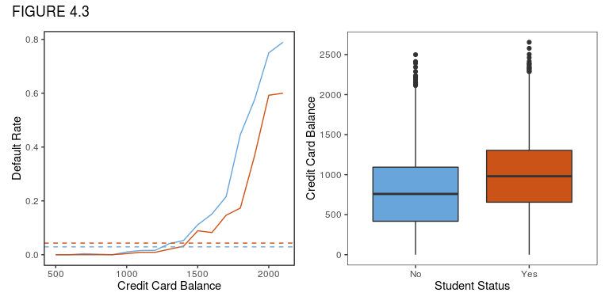

```r
colors_4.4 <- c("blue" = "#68A5DB",
                "orange" = "#CC5318")

get_bin_centres <- function(bins) {
  centres <- bins %>%
    str_extract_all("[0-9.e+]{1,}") %>%
    map(as.numeric) %>%
    map_dbl(function(x) (x[2] + x[1])/2)
  return(centres)
}

# Calculate the default rates for the y-axis by binning the balances and computing the average default rate for that bin:
Default_rates <- Default %>%
  filter(balance >= 500, balance <= 2200) %>%
  mutate(balance_binned = cut_width(balance, 100)) %>%
  group_by(balance_binned, student) %>%
  count(default) %>%
  mutate(default_rate = 1 - (n/sum(n))) %>%
  filter(default == "No") %>%  # just need one set of rates, the others are found by subtracting from 1
  mutate(bin_centres = get_bin_centres(balance_binned)) %>%
  ungroup() %>%
  dplyr::select(bin_centres, student, default_rate)

# Calculate the overall default rates for the dashed lines:
overall_default_rates <- Default %>%
  group_by(student) %>%
  count(default) %>%
  mutate(prop = n/sum(n)) %>%
  filter(default == "Yes") %>%
  dplyr::select(student, prop)

# Plot:
p1 <- Default_rates %>%
  ggplot(aes(bin_centres, default_rate)) +
  geom_line(aes(color = student), show.legend = FALSE) +
  geom_hline(yintercept = overall_default_rates$prop[overall_default_rates$student == "Yes"],
             color = colors_4.4["orange"],
             linetype = "dashed") +
  geom_hline(yintercept = overall_default_rates$prop[overall_default_rates$student == "No"],
             color = colors_4.4["blue"],
             linetype = "dashed") +
  labs(x = "Credit Card Balance", y = "Default Rate") +
  scale_x_continuous(breaks = seq(500, 2000, by = 500)) +
  scale_color_manual(values = c(colors_4.4[["blue"]], colors_4.4[["orange"]])) +
  theme(panel.grid = element_blank())

p2 <- Default %>%
  ggplot(aes(student, balance, fill = student)) +
  geom_boxplot(show.legend = FALSE) +
  scale_fill_manual(values = c(colors_4.4[["blue"]], colors_4.4[["orange"]])) +
  scale_y_continuous(name = "Credit Card Balance", seq(0, 2500, by = 500)) +
  labs(x = "Student Status") +
  theme(panel.grid = element_blank())

p1 + p2 + plot_annotation(title = "FIGURE 4.3")
```

## 4.4 Linear Discriminant Analysis

### FIGURE 4.4

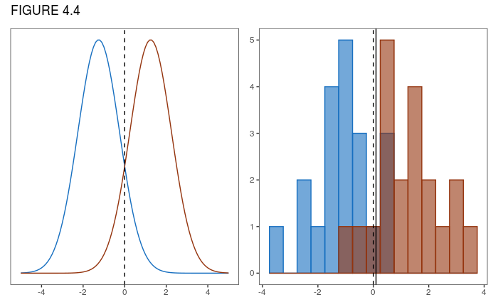

```r
# colors_4.4 <- c("green" = "#249968",
#                 "pink" = "#CA5DA4")

# The actual colors used are ugly, use the blue and brown instead:
colors_4.4 <- c("green" = ISLR_blue,
                "pink" = ISLR_brown)

# Left panel
p1 <- ggplot(tibble(x = c(-5, 5)), aes(x)) +
  stat_function(fun = dnorm,
                geom = "line",
                args = list(
                  mean = -1.25,
                  sd = 1
                ),
                color = colors_4.4["green"]) +
  stat_function(fun = dnorm,
                geom = "line",
                args = list(
                  mean = 1.25,
                  sd = 1
                ),
                color = colors_4.4["pink"]) +
  scale_x_continuous(name = NULL, breaks = c(seq(-4, 4, by = 2))) +
  scale_y_continuous(name = NULL, breaks = NULL) +
  geom_vline(xintercept = 0, linetype = "dashed") +
  theme(panel.grid = element_blank())

# Right panel:
set.seed(2)
n <- 20
mu1 <- -1.25
mu2 <- 1.25
x1 <- rnorm(n, mean = mu1, sd = 1)
x2 <- rnorm(n, mean = mu2, sd = 1)
x1.bar <- mean(x1)
x2.bar <- mean(x2)

# In this simple setting the LDA decision boundary is given by the below equation from pg 141:
LDA.boundary <- (x1.bar + x2.bar)/2

# True histogram:
p2 <- tibble(x = c(x1, x2),
       class = factor(c(rep(1, n), rep(2, n)))) %>%
  ggplot(aes(x, fill = class, color = class)) +
  geom_histogram(binwidth = 0.5,
               position = "identity",
               alpha = 0.6,
               show.legend = FALSE) +
  geom_vline(xintercept = (mu1 + mu2)/2, linetype = "dashed") + # Bayes decision boundary
  geom_vline(xintercept = LDA.boundary) + # LDA decision boundary
  scale_x_continuous(name = NULL) +
  scale_y_continuous(name = NULL) +
  scale_fill_manual(values = c("1" = colors_4.4[["green"]], "2" = colors_4.4[["pink"]])) +
  scale_color_manual(values = c("1" = colors_4.4[["green"]], "2" = colors_4.4[["pink"]])) +
  theme(panel.grid = element_blank())

p1 + p2 + plot_annotation(title = "FIGURE 4.4")
```

Generate multiple sample histograms to see how the LDA boundary changes:

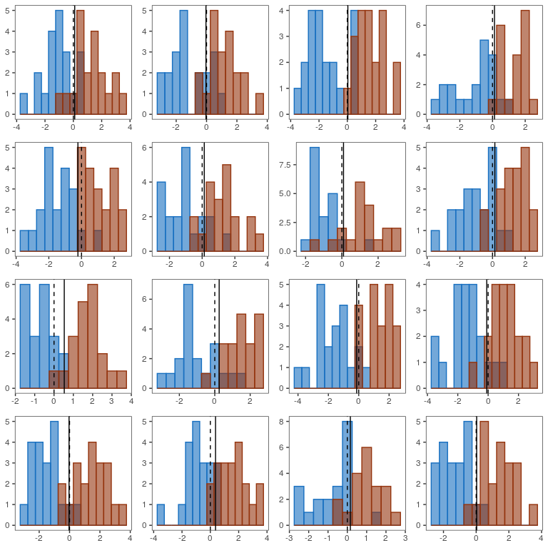

```r
set.seed(2)

k <- 16
mu1 <- -1.25
mu2 <- 1.25
G <- vector("list", k)
for(i in 1:k) {
  n <- 20
  x1 <- rnorm(n, mean = mu1, sd = 1)
  x2 <- rnorm(n, mean = mu2, sd = 1)
  x1.bar <- mean(x1)
  x2.bar <- mean(x2)
  LDA.boundary <- (x1.bar + x2.bar)/2
  G[[i]] <- tibble(x = c(x1, x2),
         class = factor(c(rep(1, n), rep(2, n)))) %>%
    ggplot(aes(x, fill = class, color = class)) +
    geom_histogram(binwidth = 0.5,
                 position = "identity",
                 alpha = 0.6,
                 show.legend = FALSE) +
    geom_vline(xintercept = (mu1 + mu2)/2, linetype = "dashed") + # Bayes decision boundary
    geom_vline(xintercept = LDA.boundary) + # LDA decision boundary
    scale_x_continuous(name = NULL) +
    scale_y_continuous(name = NULL) +
    scale_fill_manual(values = c("1" = colors_4.4[["green"]], "2" = colors_4.4[["pink"]])) +
    scale_color_manual(values = c("1" = colors_4.4[["green"]], "2" = colors_4.4[["pink"]])) +
    theme(panel.grid = element_blank())
}

cowplot::plot_grid(plotlist = G, nrow = 4)
```

The below plots include the training error for each sample. In some cases the LDA performs better than Bayes, which is the optimal classifier. This is when there is overlap that the Bayes classifier misclassifies. I think that on the *test* data it’s impossible for the LDA classifier to be better than the Bayes one, but LDA can be better on the training data, but not sure if this is correct. Could consider rerunning with a test set to calculate the test error rates.

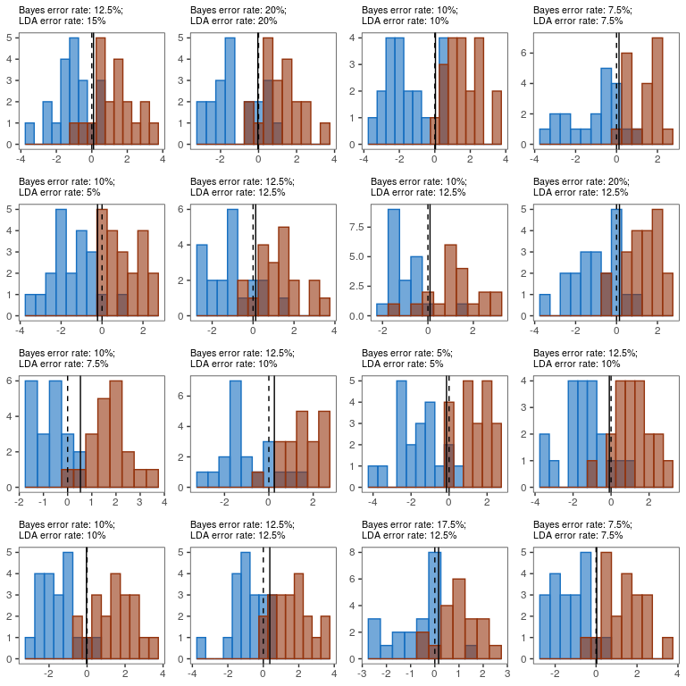

```r
set.seed(2)

k <- 16
mu1 <- -1.25
mu2 <- 1.25
bayes.boundary <- (mu1 + mu2)/2

G <- vector("list", k)
for(i in 1:k) {
  n <- 20
  x1 <- rnorm(n, mean = mu1, sd = 1)
  x2 <- rnorm(n, mean = mu2, sd = 1)
  x1.bar <- mean(x1)
  x2.bar <- mean(x2)
  LDA.boundary <- (x1.bar + x2.bar)/2

  # Training error rates:
  # Bayes classifier assigns blue if x < bayes.boundary, brown if x >= 0
  bayes.error <- 100*(sum(x1 >= bayes.boundary) + sum(x2 < bayes.boundary))/(2*n) # 100*(no of errors)/(no. of obs)
  # LDA classifier assigns blue if x < LDA.boundary, brown if x >= LDA.boundary
  LDA.error <- 100*(sum(x1 >= LDA.boundary) + sum(x2 < LDA.boundary))/(2*n) # 100*(no of errors)/(no. of obs)

  G[[i]] <- tibble(x = c(x1, x2),
         class = factor(c(rep(1, n), rep(2, n)))) %>%
    ggplot(aes(x, fill = class, color = class)) +
    geom_histogram(binwidth = 0.5,
                 position = "identity",
                 alpha = 0.6,
                 show.legend = FALSE) +
    geom_vline(xintercept = (mu1 + mu2)/2, linetype = "dashed") + # Bayes decision boundary
    geom_vline(xintercept = LDA.boundary) + # LDA decision boundary
    scale_x_continuous(name = NULL) +
    scale_y_continuous(name = NULL) +
    ggtitle(str_interp("Bayes error rate: ${round(bayes.error, 2)}%;\nLDA error rate: ${round(LDA.error, 2)}%")) +
    scale_fill_manual(values = c("1" = colors_4.4[["green"]], "2" = colors_4.4[["pink"]])) +
    scale_color_manual(values = c("1" = colors_4.4[["green"]], "2" = colors_4.4[["pink"]])) +
    theme(panel.grid = element_blank()) +
    theme(plot.title = element_text(size = 8))
}

cowplot::plot_grid(plotlist = G, nrow = 4)
```

## TODO

Consider doing 4.7 and 4.8

Error rate of LDA model on the `Default` data (page 144):

```r
lda1 <- MASS::lda(default ~ balance + student, data = Default) # page 144 outlines the model used
lda1_class <- predict(lda1, type = "response") %>%
  pluck("class")
100 * (1 - mean(lda1_class == Default$default))
```

```
[1] 2.75
```

### TABLE 4.4

```r
lda1_probs <- predict(lda1, type = "response") %>%
  pluck("posterior") %>%
  .[ , 2] # the probability of a "Yes" ( column 1 is "No")
table(if_else(lda1_probs > 0.5, "Yes", "No"), Default$default)
```

```
        No  Yes
  No  9644  252
  Yes   23   81
```

The null rate (page 144):

```r
100*mean(Default$default == "Yes")
```

```
[1] 3.33
```

### Table 4.5

Change the threshold to 20%:

```r
table(if_else(lda1_probs > 0.2, "Yes", "No"), Default$default)
```

```
        No  Yes
  No  9432  138
  Yes  235  195
```

### FIGURE 4.7

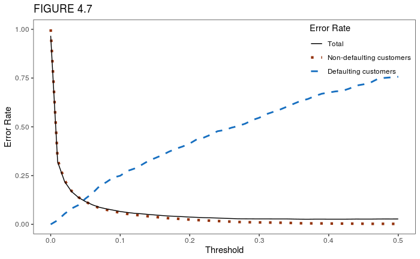

```r
# Calculates the error rate given a vector of probabilities and a threshold for the LDA model:
get_error_rate <- function(probs, threshold, class = NULL) {

  if(is.null(class)) {
    # Calculated predicted classes based on threshold:
    pred_class <- if_else(probs > threshold, "Yes", "No")
    # Error rate:
    error_rate <- 1 - mean(pred_class == Default$default)
  } else {
    # Get indexes of target class:
    index <- which(Default$default == class)
    # Calculated predicted classes based on threshold:
    pred_class <- if_else(probs[index] > threshold, "Yes", "No")
    # Error rate:
    error_rate <- 1 - mean(pred_class == Default$default[index])
  }

  return(error_rate)
}

# Create a data frame of thresholds and error rates:
thresholds <- seq(0, 0.5, 0.01)
error_rates <- data.frame(
  threshold = thresholds,
  total_error_rate = map_dbl(thresholds, ~get_error_rate(lda1_probs, threshold = .x)),
  non_default_error_rate = map_dbl(thresholds, ~get_error_rate(lda1_probs, threshold = .x, class = "No")),
  default_error_rate = map_dbl(thresholds, ~get_error_rate(lda1_probs, threshold = .x, class = "Yes"))
)

# Pivot longer and then plot:
error_rates %>%
  pivot_longer(cols = contains("rate"), names_to = "type", values_to = "error_rate") %>%
  ggplot() +
  geom_line(aes(threshold, error_rate, color = type, linetype = type, size = type)) +
  labs(x = "Threshold", y = "Error Rate",
       title = "FIGURE 4.7") +
  # Three aesthetic mappings and scales are used to recreate the ones in the book, but the plot works without them
  scale_color_manual("Error Rate",
                     breaks = c("total_error_rate", "non_default_error_rate", "default_error_rate"),
                     labels = c("Total", "Non-defaulting customers", "Defaulting customers"),
                     values = c("black", ISLR_brown, ISLR_blue)) +
  scale_linetype_manual("Error Rate",
                        breaks = c("total_error_rate", "non_default_error_rate", "default_error_rate"),
                        labels = c("Total", "Non-defaulting customers", "Defaulting customers"),
                        values = c(1, 3, 2)) +
  scale_size_manual("Error Rate",
                    breaks = c("total_error_rate", "non_default_error_rate", "default_error_rate"),
                    labels = c("Total", "Non-defaulting customers", "Defaulting customers"),
                    values = c(0.5, 1.5, 1)) +
  theme(panel.grid = element_blank(),
        legend.position = c(1, 1),
        legend.justification = c(1, 1),
        legend.background = element_blank())
```

### FIGURE 4.8

The `yardstick` package can be used to generate ROC curves:

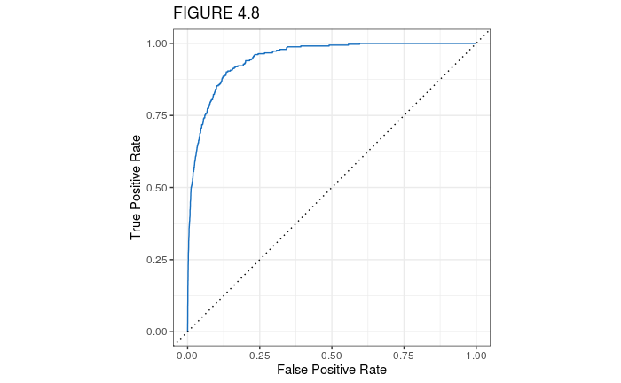

```r
data.frame(
  truth = Default$default,
  Class1 = lda1_probs
) %>%
  yardstick::roc_curve(truth, Class1, event_level = "second") %>%
  ggplot(aes(x = 1 - specificity, y = sensitivity)) +
  geom_path(color = ISLR_blue) +
  geom_abline(lty = 3) +
  labs(x = "False Positive Rate", y = "True Positive Rate",
       title = "FIGURE 4.8") +
  coord_equal()
```

[^1]: James G, Witten D, Hastie T, Tibshirani R (2013). *An Introduction to Statistical Learning: with Applications in R*. Springer, 1st edition.